# 432 Class 15

Thomas E. Love, Ph.D.

2024-03-05

## This Week’s Main Topic

**Regression Models for Count Outcomes**

- Modeling approaches illustrated in these slides
  - Poisson Regression & Zero-Inflated Poisson (ZIP)
  - Negative Binomial Regression & Zero-Inflated Negative Binomial (ZINB)
  - Two types of Hurdle model (one Poisson, one NB)

Chapters 24-26 of the Course Notes describe this material, as well as tobit regression, and some additional issues with certain types of count models.

## `countreg` and `topmodels` packages

To build rootograms to visualize the results of regression models on count outcomes, I have decided for the moment to continue to use the `countreg` and `topmodels` packages, which are currently available only on R-Forge. To install, type:

```r
install.packages("countreg", repos="http://R-Forge.R-project.org")
install.packages("topmodels", repos="http://R-Forge.R-project.org")
```

into the R Console within R Studio.

## Setup

```r
knitr::opts_chunk$set(comment=NA)
options(width = 60)

library(janitor); library(gt); library(broom)
library(mosaic); library(Hmisc); library(patchwork)
library(rsample); library(yardstick)
library(conflicted)      ## resolve conflicts
library(countreg)        ## for rootograms
library(topmodels)       ## for rootograms
library(MASS)            ## for glm.nb to fit NB models
library(pscl)            ## for zero-inflated and hurdle fits
library(lmtest)          ## for Vuong test
library(tidyverse)

conflicts_prefer(dplyr::select(), dplyr::filter(), base::sum(),
                 pscl::zeroinfl(), pscl::hurdle())

theme_set(theme_bw())
```

# An Overview

## GLMs for Count Outcomes

We want to build a generalized linear model to predict count data using one or more predictors.

Count data are non-negative integers (0, 1, 2, 3, …)

- the number of COVID-19 hospitalizations in Ohio yesterday
- the number of mutations within a particular search grid
- days in the past 30 where your mental health was poor

We’ll use the Poisson and Negative Binomial probability distributions.

## The Poisson Probability Distribution

The Poisson probability model describes the probability of a given number of events occurring in a fixed interval of time or space.

- If events occur with a constant mean rate, and independently of the time since the last event, the Poisson model is appropriate.
  - A Poisson model might fit poorly due to **overdispersion**, where the variance of Y is larger than we’d expect based on the mean of Y.

## Poisson regression

- Poisson regression assumes that the outcome Y follows a Poisson distribution, and that the logarithm of the expected value of Y (its mean) can be modeled by a linear combination of a set of predictors.
  - A Poisson regression makes the strong assumption that the variance of Y is equal to its mean.

## Dealing with Overdispersion

A Poisson model might fit poorly due to **overdispersion**, where the variance of Y is larger than we’d expect based on the mean of Y.

- *Quasipoisson* models are available which estimate an overdispersion parameter, but we’ll skip those for now.

Instead, we’ll look at other ways (especially zero-inflation and the negative binomial models) to address overdispersion.

## Negative Binomial Regression

- Negative binomial regression is a generalization of Poisson regression which loosens the assumption that the variance of Y is equal to its mean, and thus produces models which fit a broader class of data.

We will demonstrate the use of `glm.nb()` from the `MASS` package to fit negative binomial regression models.

## Zero-inflated approaches

- Both the Poisson and Negative Binomial regression approaches may under-estimate the number of zeros compared to the data.
- To better match the zero counts, zero-inflated models fit:
  - a logistic regression to predict the extra zeros, along with
  - a Poisson or Negative Binomial model to predict the counts, including some zeros.

We’ll use `zeroinfl()` from `pscl` to fit ZIP and ZINB regressions.

## Hurdle models

A hurdle model predicts the count outcome by making an assumption that there are two processes at work:

- a process that determines whether the count is zero or not zero (usually using logistic regression), and
- a process that determines the count when we know the subject has a positive count (usually using a truncated Poisson or NB model where no zeros are predicted)

We use `hurdle()` from `pscl` to fit these.

## Comparing Models

1. A key tool will be a graphical representation of the fit of the models to the count outcome, called a **rootogram**. We’ll use the rootograms produced by the `countreg` and `topmodels` packages to help us.
2. We’ll also demonstrate a Vuong hypothesis testing approach (from the `lmtest` package) to help us make decisions between various types of Poisson models or various types of Negative Binomial models on the basis of improvement in fit of things like bias-corrected AIC or BIC.

## Comparing Models

3. We’ll also demonstrate the calculation of pseudo-R square statistics for comparing models, which can be compared in a validation sample as well as in the original modeling sample.

# The `medicare` data

## The `medicare` example

Source: `NMES1988` data in R’s `AER` package, cleaned up to `medicare.csv`.

Data are a cross-section US National Medical Expenditure Survey (NMES) conducted in 1987 and 1988. The NMES is based upon a representative, national probability sample of the civilian non-institutionalized population and individuals admitted to long-term care facilities during 1987.

## Ingesting `medicare` data

The data are a subsample of individuals ages 66 and over all of whom are covered by Medicare (a public insurance program providing substantial protection against health-care costs), and some of whom also have private supplemental insurance.

```r
medicare <- read_csv("c15/data/medicare.csv", show_col_types = FALSE) |>
  mutate(across(where(is_character), as_factor),
         subject = as.character(subject))
```

## The `medicare` code book

| Variable | Description |
| --- | --- |
| `subject` | subject number (code) |
| `visits` | outcome: # of physician office visits |
| `hospital` | # of hospital stays |
| `health` | self-rated health (poor, average, excellent) |
| `chronic` | # of chronic conditions |
| `sex` | male or female |
| `school` | years of education |
| `insurance` | subject (also) has private insurance? (yes/no) |

### Today’s Goal

Predict `visits` using main effects of the 6 predictors (excluding `subject`)

## The `medicare` tibble

```r
medicare |> select(-subject)
```

```
# A tibble: 4,406 × 7
   visits hospital health  chronic sex    school insurance
    <dbl>    <dbl> <fct>     <dbl> <fct>   <dbl> <fct>
 1      5        1 average       2 male        6 yes
 2      1        0 average       2 female     10 yes
 3     13        3 poor          4 female     10 no
 4     16        1 poor          2 male        3 yes
 5      3        0 average       2 female      6 yes
 6     17        0 poor          5 female      7 no
 7      9        0 average       0 female      8 yes
 8      3        0 average       0 female      8 yes
 9      1        0 average       0 female      8 yes
10      0        0 average       0 female      8 yes
# ℹ 4,396 more rows
```

## Quick Summary of `medicare`

```r
medicare |> select(-subject) |> summary()
```

```
     visits          hospital           health
 Min.   : 0.000   Min.   :0.000   average  :3509
 1st Qu.: 1.000   1st Qu.:0.000   poor     : 554
 Median : 4.000   Median :0.000   excellent: 343
 Mean   : 5.774   Mean   :0.296
 3rd Qu.: 8.000   3rd Qu.:0.000
 Max.   :89.000   Max.   :8.000
    chronic          sex           school      insurance
 Min.   :0.000   male  :1778   Min.   : 0.00   yes:3421
 1st Qu.:1.000   female:2628   1st Qu.: 8.00   no : 985
 Median :1.000                 Median :11.00
 Mean   :1.542                 Mean   :10.29
 3rd Qu.:2.000                 3rd Qu.:12.00
 Max.   :8.000                 Max.   :18.00
```

### Adjust order of `insurance`

```r
medicare <- medicare |>
  mutate(insurance = fct_relevel(insurance, "no", "yes"))
```

I want No first, then Yes, when building models.

## Our outcome, `visits`

```r
favstats(~ visits, data = medicare)
```

```
 min Q1 median Q3 max     mean       sd    n missing
   0  1      4  8  89 5.774399 6.759225 4406       0
```

```r
describe(medicare$visits) # from Hmisc
```

```
medicare$visits
       n  missing distinct     Info     Mean      Gmd
    4406        0       60    0.992    5.774    6.227
     .05      .10      .25      .50      .75      .90
       0        0        1        4        8       13
     .95
      17

lowest :  0  1  2  3  4, highest: 63 65 66 68 89
```

```r
ggplot(medicare, aes(x = visits)) +
    geom_histogram(binwidth = 1, fill = "royalblue",
                   col = "white") +
    labs(y = "Number of Patients", x = "Number of Visits")
```

## Our outcome, `visits`

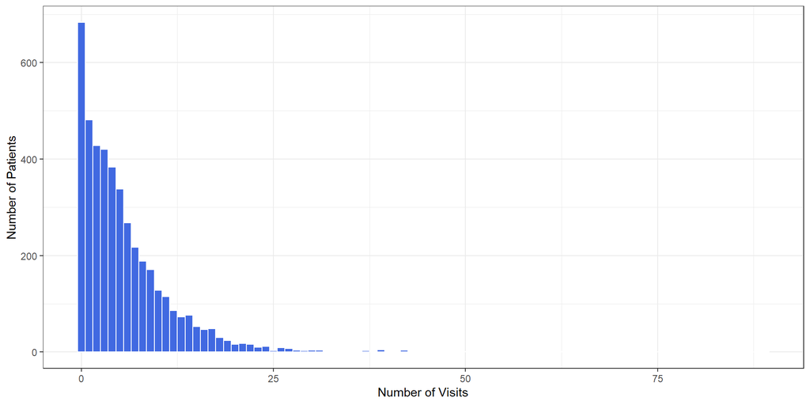

## Partitioning the Data

Creating Training and Testing Samples with `rsample` functions…

```r
set.seed(432)
med_split <- initial_split(medicare, prop = 0.75)

med_train = training(med_split)
med_test = testing(med_split)
```

I’ve held out 25% of the `medicare` data for the test sample.

```r
dim(med_train); dim(med_test)
```

```
[1] 3304    8
```

```
[1] 1102    8
```

## Reiterating the Goal

Predict `visits` using some combination of these 6 predictors…

| Predictor | Description |
| --- | --- |
| `hospital` | # of hospital stays |
| `health` | self-rated health (poor, average, excellent) |
| `chronic` | # of chronic conditions |
| `sex` | male or female |
| `school` | years of education |
| `insurance` | subject (also) has private insurance? (yes/no) |

We’ll build separate training and test samples to help us validate.

# `mod_1`: A Poisson Regression

## Poisson Regression

Assume our count data (`visits`) follows a Poisson distribution with a mean conditional on our predictors.

```r
mod_1 <- glm(visits ~ hospital + health + chronic +
                  sex + school + insurance,
              data = med_train, family = "poisson")
```

The Poisson model uses a logarithm as its link function, so the model is actually predicting log(`visits`).

Note that we’re fitting the model here using the training sample alone.

## Complete `mod_1` Summary

```r
summary(mod_1)
```

```
Call:
glm(formula = visits ~ hospital + health + chronic + sex + school +
    insurance, family = "poisson", data = med_train)

Coefficients:
                 Estimate Std. Error z value Pr(>|z|)
(Intercept)      0.886576   0.028813  30.770  < 2e-16 ***
hospital         0.163555   0.006710  24.374  < 2e-16 ***
healthpoor       0.309610   0.020244  15.294  < 2e-16 ***
healthexcellent -0.358758   0.034875 -10.287  < 2e-16 ***
chronic          0.137349   0.005266  26.082  < 2e-16 ***
sexfemale        0.098325   0.014805   6.641 3.11e-11 ***
school           0.031258   0.002111  14.808  < 2e-16 ***
insuranceyes     0.200249   0.019484  10.278  < 2e-16 ***
---
Signif. codes:
0 '***' 0.001 '**' 0.01 '*' 0.05 '.' 0.1 ' ' 1

(Dispersion parameter for poisson family taken to be 1)

    Null deviance: 20618  on 3303  degrees of freedom
Residual deviance: 17598  on 3296  degrees of freedom
AIC: 27232

Number of Fisher Scoring iterations: 5
```

## `mod_1` (Poisson) model coefficients

```r
tidy(mod_1) |> gt() |> fmt_number(decimals = 3)
```

| term | estimate | std.error | statistic | p.value |
| --- | --- | --- | --- | --- |
| (Intercept) | 0.887 | 0.029 | 30.770 | 0.000 |
| hospital | 0.164 | 0.007 | 24.374 | 0.000 |
| healthpoor | 0.310 | 0.020 | 15.294 | 0.000 |
| healthexcellent | −0.359 | 0.035 | −10.287 | 0.000 |
| chronic | 0.137 | 0.005 | 26.082 | 0.000 |
| sexfemale | 0.098 | 0.015 | 6.641 | 0.000 |
| school | 0.031 | 0.002 | 14.808 | 0.000 |
| insuranceyes | 0.200 | 0.019 | 10.278 | 0.000 |

Harry and Larry have the same values for all other predictors but only Harry has private insurance. `mod_1` estimates Harry’s log(`visits`) to be 0.2 larger than Larry’s log(`visits`).

## Visualize fit: (Hanging) Rootogram

```r
plot(rootogram(mod_1, plot = FALSE), xlim = c(0, 90),
               main = "Rootogram for mod_1: Poisson")
```

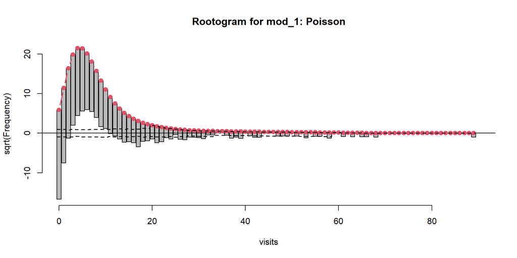

See the next slide for details on how to interpret this…

## Interpreting the Rootogram

- The red curved line is the theoretical Poisson fit.
- “Hanging” from each point on the red line is a bar, the height of which represents the observed counts.
  - A bar hanging below 0 indicates that the model under-predicts that value. (Model predicts fewer values than the data show.)
  - A bar hanging above 0 indicates over-prediction of that value. (Model predicts more values than the data show.)
- The counts have been transformed with a square root transformation to prevent smaller counts from getting obscured and overwhelmed by larger counts.
- https://arxiv.org/pdf/1605.01311 has more on rootograms.
- Our Poisson model (`mod_1`) doesn’t fit enough zeros or ones, and fits too many 3-12 values, then not enough of the higher values.

## Store `mod_1` Predictions

We’ll use the `augment` function to store the predictions within our training sample. Note the use of `"response"` to predict `visits`, not log(`visits`).

```r
mod_1_aug <- augment(mod_1, med_train,
                     type.predict = "response")

mod_1_aug |> select(subject, visits, .fitted) |> head(3)
```

```
# A tibble: 3 × 3
  subject visits .fitted
  <chr>    <dbl>   <dbl>
1 355         19    5.02
2 2661         3    4.21
3 2895         0    4.65
```

## Training Sample `mod_1` Fit

Within our training sample, `mod_1_aug` now contains both the actual counts (`visits`) and the predicted counts (in `.fitted`) from `mod_1`. We’ll summarize the fit…

```r
mets <- metric_set(rsq, rmse, mae)
mod_1_summary <-
  mets(mod_1_aug, truth = visits, estimate = .fitted) |>
  mutate(model = "mod_1") |> relocate(model)
mod_1_summary |> gt() |> fmt_number(decimals = 3)
```

| model | .metric | .estimator | .estimate |
| --- | --- | --- | --- |
| mod_1 | rsq | standard | 0.100 |
| mod_1 | rmse | standard | 6.594 |
| mod_1 | mae | standard | 4.189 |

These will become interesting as we build additional models.

# `mod_2`: A Negative Binomial Regression

## Fitting the Negative Binomial Model

The negative binomial model requires the estimation of an additional parameter, called $\theta$ (theta). The default link for this generalized linear model is also a logarithm, like the Poisson.

```r
mod_2 <- MASS::glm.nb(visits ~ hospital + health + chronic +
                  sex + school + insurance,
              data = med_train)
```

The estimated dispersion parameter value $\theta$ is…

```r
summary(mod_2)$theta
```

```
[1] 1.21109
```

The Poisson model is essentially the negative binomial model assuming a known $\theta = 1$.

## Complete `mod_2` summary

```r
summary(mod_2)
```

```
Call:
MASS::glm.nb(formula = visits ~ hospital + health + chronic +
    sex + school + insurance, data = med_train, init.theta = 1.211089878,
    link = log)

Coefficients:
                 Estimate Std. Error z value Pr(>|z|)
(Intercept)      0.765746   0.065602  11.673  < 2e-16 ***
hospital         0.224205   0.022745   9.857  < 2e-16 ***
healthpoor       0.360067   0.055608   6.475 9.47e-11 ***
healthexcellent -0.335591   0.070353  -4.770 1.84e-06 ***
chronic          0.169070   0.013887  12.174  < 2e-16 ***
sexfemale        0.109443   0.035920   3.047  0.00231 **
school           0.030763   0.005037   6.107 1.02e-09 ***
insuranceyes     0.237080   0.045780   5.179 2.23e-07 ***
---
Signif. codes:
0 '***' 0.001 '**' 0.01 '*' 0.05 '.' 0.1 ' ' 1

(Dispersion parameter for Negative Binomial(1.2111) family taken to be 1)

    Null deviance: 4341.7  on 3303  degrees of freedom
Residual deviance: 3783.1  on 3296  degrees of freedom
AIC: 18328

Number of Fisher Scoring iterations: 1

              Theta:  1.2111
          Std. Err.:  0.0388

 2 x log-likelihood:  -18309.8280
```

## `mod_2` (NB) coefficients

```r
tidy(mod_2) |> gt() |> fmt_number(decimals = 3)
```

| term | estimate | std.error | statistic | p.value |
| --- | --- | --- | --- | --- |
| (Intercept) | 0.766 | 0.066 | 11.673 | 0.000 |
| hospital | 0.224 | 0.023 | 9.857 | 0.000 |
| healthpoor | 0.360 | 0.056 | 6.475 | 0.000 |
| healthexcellent | −0.336 | 0.070 | −4.770 | 0.000 |
| chronic | 0.169 | 0.014 | 12.174 | 0.000 |
| sexfemale | 0.109 | 0.036 | 3.047 | 0.002 |
| school | 0.031 | 0.005 | 6.107 | 0.000 |
| insuranceyes | 0.237 | 0.046 | 5.179 | 0.000 |

## Rootogram for NB Model

```r
plot(rootogram(mod_2, plot = FALSE), xlim = c(0, 90),
               main = "Rootogram for mod_2: Negative Binomial")
```

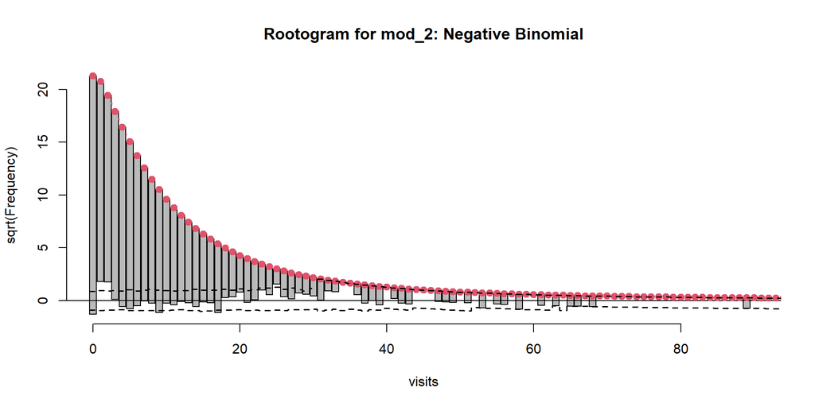

Does this look better than the Poisson rootogram?

## Store `mod_2` Predictions

```r
mod_2_aug <- augment(mod_2, med_train, type.predict = "response")

mod_2_aug |> select(subject, visits, .fitted) |> head(3)
```

```
# A tibble: 3 × 3
  subject visits .fitted
  <chr>    <dbl>   <dbl>
1 355         19    5.22
2 2661         3    4.08
3 2895         0    4.39
```

- Note that this *may* throw a warning about who maintains tidiers for `negbin` models. I’d silence it, as I have here.

## Training Fit for `mod_2`

`mod_2_aug` has actual (`visits`) and predicted counts (in `.fitted`.)

```r
mod_2_summary <-
  mets(mod_2_aug, truth = visits, estimate = .fitted) |>
  mutate(model = "mod_2") |> relocate(model)
mod_2_summary |> gt() |> fmt_number(decimals = 3)
```

| model | .metric | .estimator | .estimate |
| --- | --- | --- | --- |
| mod_2 | rsq | standard | 0.078 |
| mod_2 | rmse | standard | 6.941 |
| mod_2 | mae | standard | 4.252 |

## Training Sample So Far

The reasonable things to summarize in sample look like the impressions from the rootograms and the summaries we’ve prepared so far.

| Model | Rootogram impressions |
| --- | --- |
| `mod_1` (P) | Many problems. Data appear overdispersed. |
| `mod_2` (NB) | Still not enough zeros; some big predictions. |

## Training Sample Summaries

```r
bind_rows(mod_1_summary, mod_2_summary) |>
  pivot_wider(names_from = model,
              values_from = .estimate) |>
  gt() |> fmt_number(decimals = 3) |>
  tab_options(table.font.size = 20)
```

| .metric | .estimator | mod_1 | mod_2 |
| --- | --- | --- | --- |
| rsq | standard | 0.100 | 0.078 |
| rmse | standard | 6.594 | 6.941 |
| mae | standard | 4.189 | 4.252 |

# `mod_3`: Zero-Inflated Poisson (ZIP) Model

## Zero-Inflated Poisson (ZIP) model

The zero-inflated Poisson model describes count data with an excess of zero counts.

The model posits that there are two processes involved:

- a logistic regression model is used to predict excess zeros
- while a Poisson model is used to predict the counts

We’ll use the `pscl` package to fit zero-inflated models.

```r
mod_3 <- pscl::zeroinfl(visits ~ hospital + health +
                    chronic + sex + school + insurance,
                    data = med_train)
```

## `mod_3` ZIP coefficients

Sadly, there’s no `broom` tidying functions for these zero-inflated models.

```r
summary(mod_3)
```

```
Call:
pscl::zeroinfl(formula = visits ~ hospital + health +
    chronic + sex + school + insurance, data = med_train)

Pearson residuals:
    Min      1Q  Median      3Q     Max
-5.4401 -1.1618 -0.4769  0.5699 24.3630

Count model coefficients (poisson with log link):
                 Estimate Std. Error z value Pr(>|z|)
(Intercept)      1.298380   0.029608  43.853  < 2e-16 ***
hospital         0.160449   0.006780  23.664  < 2e-16 ***
healthpoor       0.302326   0.020022  15.099  < 2e-16 ***
healthexcellent -0.281826   0.035775  -7.878 3.33e-15 ***
chronic          0.097090   0.005420  17.913  < 2e-16 ***
sexfemale        0.056219   0.014934   3.765 0.000167 ***
school           0.023367   0.002139  10.924  < 2e-16 ***
insuranceyes     0.093169   0.019794   4.707 2.52e-06 ***

Zero-inflation model coefficients (binomial with logit link):
                Estimate Std. Error z value Pr(>|z|)
(Intercept)      0.25623    0.16807   1.525 0.127381
hospital        -0.29538    0.10252  -2.881 0.003962 **
healthpoor      -0.09642    0.19067  -0.506 0.613093
healthexcellent  0.32851    0.16898   1.944 0.051891 .
chronic         -0.49292    0.05183  -9.510  < 2e-16 ***
sexfemale       -0.36437    0.10295  -3.539 0.000401 ***
school          -0.06165    0.01410  -4.373 1.22e-05 ***
insuranceyes    -0.66566    0.11996  -5.549 2.87e-08 ***
---
Signif. codes:  0 '***' 0.001 '**' 0.01 '*' 0.05 '.' 0.1 ' ' 1

Number of iterations in BFGS optimization: 20
Log-likelihood: -1.222e+04 on 16 Df
```

## Rootogram for ZIP model

```r
plot(rootogram(mod_3, plot = FALSE), xlim = c(0, 90),
               main = "Rootogram for mod_3: ZIP")
```

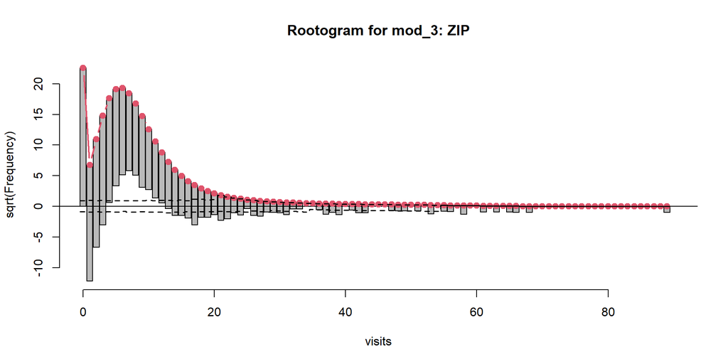

## Store `mod_3` Predictions

We have no `augment` or other `broom` functions available for zero-inflated models, so …

```r
mod_3_aug <- med_train |>
    mutate(".fitted" = predict(mod_3, type = "response"),
           ".resid" = resid(mod_3, type = "response"))

mod_3_aug |> select(subject, visits, .fitted, .resid) |>
  head(3)
```

```
# A tibble: 3 × 4
  subject visits .fitted .resid
  <chr>    <dbl>   <dbl>  <dbl>
1 355         19    5.31  13.7
2 2661         3    4.21  -1.21
3 2895         0    4.59  -4.59
```

## Training: `mod_3` Fit

`mod_3_aug` now has actual (`visits`) and predicted counts (in `.fitted`) from `mod_3`, just as we set up for the previous two models.

```r
mod_3_summary <-
  mets(mod_3_aug, truth = visits, estimate = .fitted) |>
  mutate(model = "mod_3") |> relocate(model)
mod_3_summary |> gt() |> fmt_number(decimals = 3)
```

| model | .metric | .estimator | .estimate |
| --- | --- | --- | --- |
| mod_3 | rsq | standard | 0.108 |
| mod_3 | rmse | standard | 6.560 |
| mod_3 | mae | standard | 4.164 |

## Training: Through `mod_3`

```r
bind_rows(mod_1_summary, mod_2_summary, mod_3_summary) |>
  pivot_wider(names_from = model,
              values_from = .estimate) |>
  gt() |> fmt_number(decimals = 3) |>
  tab_options(table.font.size = 20)
```

| .metric | .estimator | mod_1 | mod_2 | mod_3 |
| --- | --- | --- | --- | --- |
| rsq | standard | 0.100 | 0.078 | 0.108 |
| rmse | standard | 6.594 | 6.941 | 6.560 |
| mae | standard | 4.189 | 4.252 | 4.164 |

Remember we want a larger $R^2$ and smaller values of RMSE and MAE.

## Comparing models with Vuong

Vuong’s test compares predicted probabilities (for each count) in two non-nested models. How about Poisson vs. ZIP?

```r
vuong(mod_1, mod_3)
```

```
Vuong Non-Nested Hypothesis Test-Statistic:
(test-statistic is asymptotically distributed N(0,1) under the
 null that the models are indistinguishible)
-------------------------------------------------------------
              Vuong z-statistic             H_A    p-value
Raw                   -14.59671 model2 > model1 < 2.22e-16
AIC-corrected         -14.51271 model2 > model1 < 2.22e-16
BIC-corrected         -14.25638 model2 > model1 < 2.22e-16
```

The large negative z-statistic indicates `mod_3` (ZIP) fits better than `mod_1` (Poisson) in our training sample.

# `mod_4`: Zero-Inflated Negative Binomial (ZINB) Model

## Zero-Inflated Negative Binomial (ZINB) model

As in the ZIP, we assume there are two processes involved:

- a logistic regression model is used to predict excess zeros
- while a negative binomial model is used to predict the counts

We’ll use the `pscl` package again and the `zeroinfl` function.

```r
mod_4 <- zeroinfl(visits ~ hospital + health + chronic +
                  sex + school + insurance,
              dist = "negbin", data = med_train)
```

## `mod_4` summary

```r
summary(mod_4)
```

```
Call:
zeroinfl(formula = visits ~ hospital + health + chronic +
    sex + school + insurance, data = med_train, dist = "negbin")

Pearson residuals:
    Min      1Q  Median      3Q     Max
-1.1943 -0.7072 -0.2773  0.3347 17.2775

Count model coefficients (negbin with log link):
                 Estimate Std. Error z value Pr(>|z|)
(Intercept)      1.059477   0.070188  15.095  < 2e-16 ***
hospital         0.207087   0.023460   8.827  < 2e-16 ***
healthpoor       0.333853   0.052720   6.333 2.41e-10 ***
healthexcellent -0.288168   0.073627  -3.914 9.08e-05 ***
chronic          0.126107   0.013737   9.180  < 2e-16 ***
sexfemale        0.069573   0.035975   1.934  0.05312 .
school           0.025015   0.004983   5.020 5.18e-07 ***
insuranceyes     0.151514   0.048328   3.135  0.00172 **
Log(theta)       0.389048   0.040783   9.539  < 2e-16 ***

Zero-inflation model coefficients (binomial with logit link):
                Estimate Std. Error z value Pr(>|z|)
(Intercept)      0.45740    0.31049   1.473  0.14071
hospital        -0.84886    0.57525  -1.476  0.14004
healthpoor      -0.33730    0.70243  -0.480  0.63109
healthexcellent  0.27653    0.33753   0.819  0.41262
chronic         -1.16806    0.20536  -5.688 1.29e-08 ***
sexfemale       -0.56382    0.24204  -2.329  0.01983 *
school          -0.09233    0.03157  -2.925  0.00345 **
insuranceyes    -1.00819    0.27195  -3.707  0.00021 ***
---
Signif. codes:  0 '***' 0.001 '**' 0.01 '*' 0.05 '.' 0.1 ' ' 1

Theta = 1.4756
Number of iterations in BFGS optimization: 28
Log-likelihood: -9102 on 17 Df
```

## Rootogram for ZINB model

```r
plot(rootogram(mod_4, plot = FALSE), xlim = c(0, 90),
               main = "Rootogram for mod_4: ZINB")
```

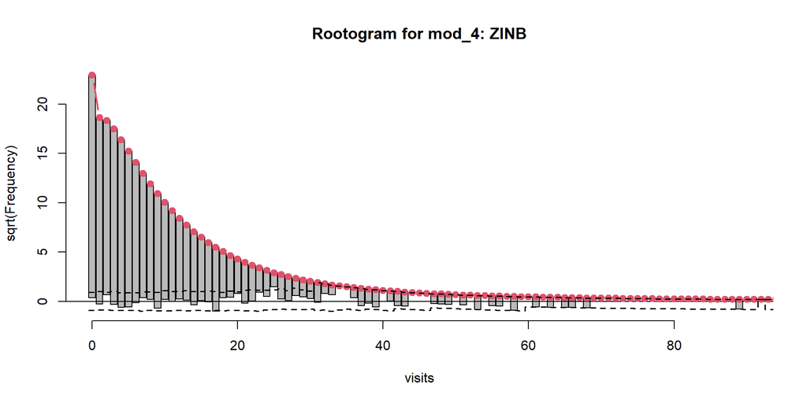

## Store `mod_4` Predictions

Again, there is no `augment` or other `broom` functions available for zero-inflated models, so …

```r
mod_4_aug <- med_train |>
    mutate(".fitted" = predict(mod_4, type = "response"),
           ".resid" = resid(mod_4, type = "response"))

mod_4_aug |> select(subject, visits, .fitted, .resid) |>
  head(3)
```

```
# A tibble: 3 × 4
  subject visits .fitted .resid
  <chr>    <dbl>   <dbl>  <dbl>
1 355         19    5.29  13.7
2 2661         3    4.47  -1.47
3 2895         0    4.57  -4.57
```

## Training Sample `mod_4` Fit

`mod_4_aug` now has actual (`visits`) and predicted counts (in `.fitted`) from `mod_4`.

```r
mod_4_summary <-
  mets(mod_4_aug, truth = visits, estimate = .fitted) |>
  mutate(model = "mod_4") |> relocate(model)
mod_4_summary |> gt() |> fmt_number(decimals = 3)
```

| model | .metric | .estimator | .estimate |
| --- | --- | --- | --- |
| mod_4 | rsq | standard | 0.094 |
| mod_4 | rmse | standard | 6.709 |
| mod_4 | mae | standard | 4.191 |

## Training Sample through `mod_4`

```r
bind_rows(mod_1_summary, mod_2_summary,
          mod_3_summary, mod_4_summary) |>
  pivot_wider(names_from = model,
              values_from = .estimate) |>
  gt() |> fmt_number(decimals = 3) |>
  tab_options(table.font.size = 20)
```

| .metric | .estimator | mod_1 | mod_2 | mod_3 | mod_4 |
| --- | --- | --- | --- | --- | --- |
| rsq | standard | 0.100 | 0.078 | 0.108 | 0.094 |
| rmse | standard | 6.594 | 6.941 | 6.560 | 6.709 |
| mae | standard | 4.189 | 4.252 | 4.164 | 4.191 |

What do you think?

## Comparing models with Vuong

How about Negative Binomial vs. ZINB?

```r
vuong(mod_4, mod_2)
```

```
Vuong Non-Nested Hypothesis Test-Statistic:
(test-statistic is asymptotically distributed N(0,1) under the
 null that the models are indistinguishible)
-------------------------------------------------------------
              Vuong z-statistic             H_A    p-value
Raw                    4.808304 model1 > model2 7.6108e-07
AIC-corrected          4.082004 model1 > model2 2.2324e-05
BIC-corrected          1.865741 model1 > model2   0.031039
```

The large positive z-statistics indicate `mod_4` (ZINB) fits better than `mod_2` (Negative Binomial) in our training sample.

# Validation in the Test Sample for our Four Models?

## Validation: Test Sample Predictions

Predict the `visit` counts for each subject in our test sample.

```r
test_1 <- predict(mod_1, newdata = med_test,
                  type.predict = "response")
test_2 <- predict(mod_2, newdata = med_test,
                  type.predict = "response")
test_3 <- predict(mod_3, newdata = med_test,
                  type.predict = "response")
test_4 <- predict(mod_4, newdata = med_test,
                  type.predict = "response")
```

## Create a Tibble with Predictions

Combine the various predictions into a tibble with the original data.

```r
test_res <- bind_cols(med_test,
              pre_m1 = test_1, pre_m2 = test_2,
              pre_m3 = test_3, pre_m4 = test_4)

names(test_res)
```

```
 [1] "subject"   "visits"    "hospital"  "health"
 [5] "chronic"   "sex"       "school"    "insurance"
 [9] "pre_m1"    "pre_m2"    "pre_m3"    "pre_m4"
```

## Summarize fit in test sample for each model

```r
m1_sum <- mets(test_res, truth = visits, estimate = pre_m1) |>
  mutate(model = "mod_1")
m2_sum <- mets(test_res, truth = visits, estimate = pre_m2) |>
  mutate(model = "mod_2")
m3_sum <- mets(test_res, truth = visits, estimate = pre_m3) |>
  mutate(model = "mod_3")
m4_sum <- mets(test_res, truth = visits, estimate = pre_m4) |>
  mutate(model = "mod_4")

test_sum <- bind_rows(m1_sum, m2_sum, m3_sum, m4_sum)
```

## Validation Results: Four Models

```r
test_sum <- bind_rows(m1_sum, m2_sum, m3_sum, m4_sum) |>
  pivot_wider(names_from = model,
              values_from = .estimate)

test_sum |>
  select(-.estimator) |>
  gt() |> fmt_number(decimals = 3) |>
  tab_options(table.font.size = 20)
```

| .metric | mod_1 | mod_2 | mod_3 | mod_4 |
| --- | --- | --- | --- | --- |
| rsq | 0.103 | 0.108 | 0.099 | 0.097 |
| rmse | 7.212 | 7.205 | 5.907 | 5.967 |
| mae | 4.455 | 4.450 | 3.994 | 4.009 |

- Which model looks best? Is it an obvious choice?

# Hurdle Models

## The Hurdle Model

The hurdle model is a two-part model that specifies one process for zero counts and another process for positive counts. The idea is that positive counts occur once a threshold is crossed, or put another way, a hurdle is cleared. If the hurdle is not cleared, then we have a count of 0.

- The first part of the model is typically a **binary logistic regression** model. This models whether an observation takes a positive count or not.
- The second part of the model is usually a truncated Poisson or Negative Binomial model. Truncated means we’re only fitting positive counts, and not zeros.

# `mod_5`: Poisson-Logistic Hurdle Model

## Fitting a Hurdle Model / Poisson-Logistic

In fitting a hurdle model to our medicare training data, the interpretation would be that one process governs whether a patient visits a doctor or not, and another process governs how many visits are made.

## The `mod_5` model

```r
mod_5 <- hurdle(visits ~ hospital + health + chronic +
                  sex + school + insurance,
              dist = "poisson", zero.dist = "binomial",
              data = med_train)
mod_5
```

```
Call:
hurdle(formula = visits ~ hospital + health + chronic +
    sex + school + insurance, data = med_train, dist = "poisson",
    zero.dist = "binomial")

Count model coefficients (truncated poisson with log link):
    (Intercept)         hospital       healthpoor
        1.29892          0.16041          0.30243
healthexcellent          chronic        sexfemale
       -0.28116          0.09697          0.05611
         school     insuranceyes
        0.02332          0.09351

Zero hurdle model coefficients (binomial with logit link):
    (Intercept)         hospital       healthpoor
        -0.2998           0.3044           0.1114
healthexcellent          chronic        sexfemale
        -0.3705           0.4970           0.3652
         school     insuranceyes
         0.0637           0.6625
```

## `mod_5` summary

```r
summary(mod_5)
```

```
Call:
hurdle(formula = visits ~ hospital + health + chronic +
    sex + school + insurance, data = med_train, dist = "poisson",
    zero.dist = "binomial")

Pearson residuals:
    Min      1Q  Median      3Q     Max
-5.4472 -1.1621 -0.4769  0.5698 24.3403

Count model coefficients (truncated poisson with log link):
                 Estimate Std. Error z value Pr(>|z|)
(Intercept)      1.298920   0.029612  43.865  < 2e-16 ***
hospital         0.160410   0.006781  23.656  < 2e-16 ***
healthpoor       0.302432   0.020026  15.102  < 2e-16 ***
healthexcellent -0.281162   0.035755  -7.864 3.73e-15 ***
chronic          0.096971   0.005417  17.901  < 2e-16 ***
sexfemale        0.056109   0.014933   3.757 0.000172 ***
school           0.023321   0.002138  10.907  < 2e-16 ***
insuranceyes     0.093508   0.019789   4.725 2.30e-06 ***
Zero hurdle model coefficients (binomial with logit link):
                Estimate Std. Error z value Pr(>|z|)
(Intercept)     -0.29978    0.16500  -1.817 0.069240 .
hospital         0.30445    0.10235   2.975 0.002934 **
healthpoor       0.11138    0.18993   0.586 0.557605
healthexcellent -0.37054    0.16200  -2.287 0.022179 *
chronic          0.49699    0.05112   9.722  < 2e-16 ***
sexfemale        0.36524    0.10116   3.610 0.000306 ***
school           0.06370    0.01382   4.611 4.01e-06 ***
insuranceyes     0.66251    0.11789   5.620 1.91e-08 ***
---
Signif. codes:  0 '***' 0.001 '**' 0.01 '*' 0.05 '.' 0.1 ' ' 1

Number of iterations in BFGS optimization: 14
Log-likelihood: -1.222e+04 on 16 Df
```

## Rootogram for Poisson-Logistic Hurdle model

```r
plot(rootogram(mod_5, plot = FALSE), xlim = c(0, 90),
               main = "mod_5 Poisson-Logistic Hurdle")
```

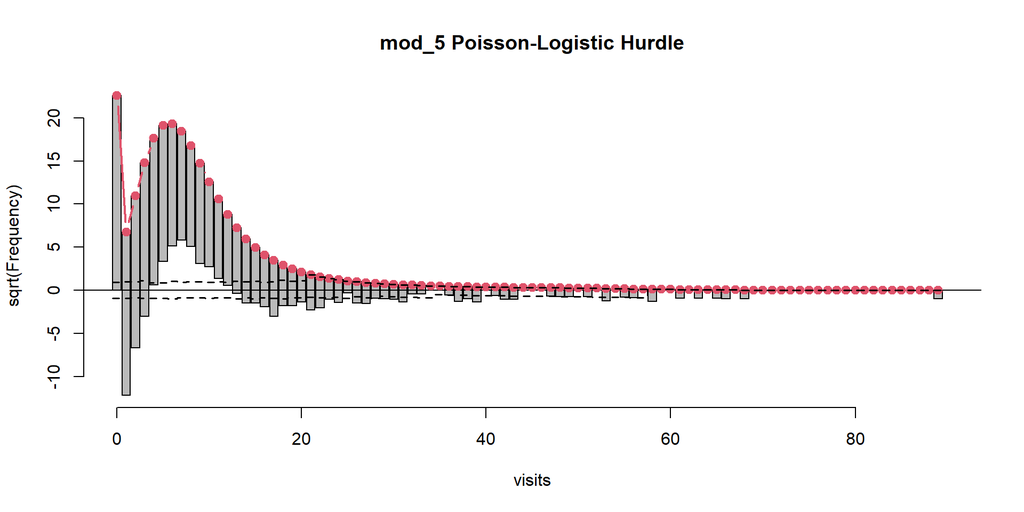

## Store `mod_5` Predictions

No `augment` or other `broom` functions for hurdle models, so …

```r
mod_5_aug <- med_train |>
    mutate(".fitted" = predict(mod_5, type = "response"),
           ".resid" = resid(mod_5, type = "response"))

mod_5_aug |> select(subject, visits, .fitted, .resid) |>
  head(3)
```

```
# A tibble: 3 × 4
  subject visits .fitted .resid
  <chr>    <dbl>   <dbl>  <dbl>
1 355         19    5.32  13.7
2 2661         3    4.20  -1.20
3 2895         0    4.59  -4.59
```

## Training Sample `mod_5` Fit

```r
mod_5_summary <-
  mets(mod_5_aug, truth = visits, estimate = .fitted) |>
  mutate(model = "mod_5") |> relocate(model)
mod_5_summary |> gt() |> fmt_number(decimals = 3)
```

| model | .metric | .estimator | .estimate |
| --- | --- | --- | --- |
| mod_5 | rsq | standard | 0.108 |
| mod_5 | rmse | standard | 6.560 |
| mod_5 | mae | standard | 4.164 |

## Training Sample through `mod_5`

```r
bind_rows(mod_1_summary, mod_2_summary, mod_3_summary,
          mod_4_summary, mod_5_summary) |>
  pivot_wider(names_from = model,
              values_from = .estimate) |>
  gt() |> fmt_number(decimals = 3) |>
  tab_options(table.font.size = 20)
```

| .metric | .estimator | mod_1 | mod_2 | mod_3 | mod_4 | mod_5 |
| --- | --- | --- | --- | --- | --- | --- |
| rsq | standard | 0.100 | 0.078 | 0.108 | 0.094 | 0.108 |
| rmse | standard | 6.594 | 6.941 | 6.560 | 6.709 | 6.560 |
| mae | standard | 4.189 | 4.252 | 4.164 | 4.191 | 4.164 |

What do you think?

## Are ZIP and Poisson-Logistic Hurdle the Same?

```r
temp_check <- tibble(
  subject = mod_3_aug$subject,
  visits = mod_3_aug$visits,
  pred_zip = mod_3_aug$.fitted,
  pred_hur = mod_5_aug$.fitted,
  diff = pred_hur - pred_zip)

favstats(~ diff, data = temp_check)
```

```
        min            Q1       median           Q3
 -0.0241247 -0.0004086227 0.0003036167 0.0009285733
        max         mean          sd    n missing
 0.03270967 0.0003302558 0.003050025 3304       0
```

## Vuong test: `mod_3` vs. `mod_5`

```r
vuong(mod_3, mod_5)
```

```
Vuong Non-Nested Hypothesis Test-Statistic:
(test-statistic is asymptotically distributed N(0,1) under the
 null that the models are indistinguishible)
-------------------------------------------------------------
              Vuong z-statistic             H_A  p-value
Raw                    1.913241 model1 > model2 0.027859
AIC-corrected          1.913241 model1 > model2 0.027859
BIC-corrected          1.913241 model1 > model2 0.027859
```

# `mod_6`: Negative Binomial-Logistic Hurdle Model

## Hurdle Model / NB-Logistic

```r
mod_6 <- hurdle(visits ~ hospital + health + chronic +
                  sex + school + insurance,
              dist = "negbin", zero.dist = "binomial",
              data = med_train)
mod_6
```

```
Call:
hurdle(formula = visits ~ hospital + health + chronic +
    sex + school + insurance, data = med_train, dist = "negbin",
    zero.dist = "binomial")

Count model coefficients (truncated negbin with log link):
    (Intercept)         hospital       healthpoor
        1.07299          0.21828          0.36531
healthexcellent          chronic        sexfemale
       -0.30074          0.12372          0.05795
         school     insuranceyes
        0.02429          0.13122
Theta = 1.406

Zero hurdle model coefficients (binomial with logit link):
    (Intercept)         hospital       healthpoor
        -0.2998           0.3044           0.1114
healthexcellent          chronic        sexfemale
        -0.3705           0.4970           0.3652
         school     insuranceyes
         0.0637           0.6625
```

## `mod_6` Summary

```r
summary(mod_6)
```

```
Call:
hurdle(formula = visits ~ hospital + health + chronic +
    sex + school + insurance, data = med_train, dist = "negbin",
    zero.dist = "binomial")

Pearson residuals:
    Min      1Q  Median      3Q     Max
-1.1756 -0.7080 -0.2771  0.3371 17.4791

Count model coefficients (truncated negbin with log link):
                 Estimate Std. Error z value Pr(>|z|)
(Intercept)      1.072988   0.072095  14.883  < 2e-16 ***
hospital         0.218281   0.024288   8.987  < 2e-16 ***
healthpoor       0.365310   0.054624   6.688 2.27e-11 ***
healthexcellent -0.300745   0.076626  -3.925 8.68e-05 ***
chronic          0.123717   0.014253   8.680  < 2e-16 ***
sexfemale        0.057948   0.037229   1.557  0.11958
school           0.024290   0.005156   4.711 2.46e-06 ***
insuranceyes     0.131216   0.049295   2.662  0.00777 **
Log(theta)       0.340775   0.049007   6.954 3.56e-12 ***
Zero hurdle model coefficients (binomial with logit link):
                Estimate Std. Error z value Pr(>|z|)
(Intercept)     -0.29978    0.16500  -1.817 0.069240 .
hospital         0.30445    0.10235   2.975 0.002934 **
healthpoor       0.11138    0.18993   0.586 0.557605
healthexcellent -0.37054    0.16200  -2.287 0.022179 *
chronic          0.49699    0.05112   9.722  < 2e-16 ***
sexfemale        0.36524    0.10116   3.610 0.000306 ***
school           0.06370    0.01382   4.611 4.01e-06 ***
insuranceyes     0.66251    0.11789   5.620 1.91e-08 ***
---
Signif. codes:  0 '***' 0.001 '**' 0.01 '*' 0.05 '.' 0.1 ' ' 1

Theta: count = 1.406
Number of iterations in BFGS optimization: 16
Log-likelihood: -9102 on 17 Df
```

## Rootogram for NB-Logistic Hurdle model

```r
plot(rootogram(mod_6, plot = FALSE), xlim = c(0, 90),
               main = "mod_6 Neg. Bin.-Logistic Hurdle")
```

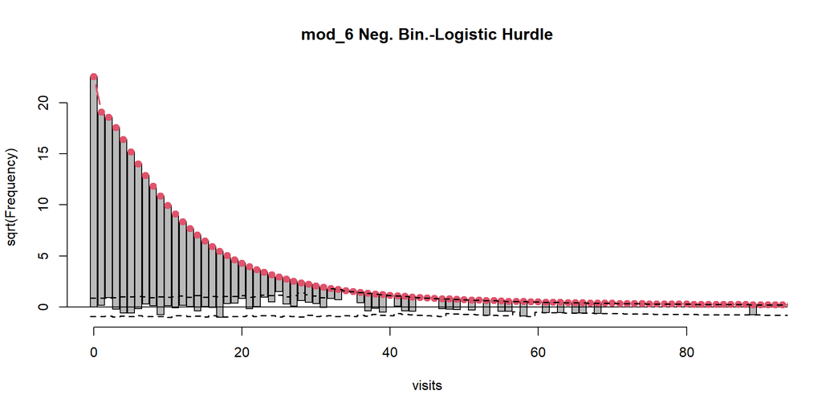

## Store `mod_6` Predictions

```r
mod_6_aug <- med_train |>
    mutate(".fitted" = predict(mod_6, type = "response"),
           ".resid" = resid(mod_6, type = "response"))

mod_6_aug |> select(subject, visits, .fitted, .resid) |>
  head(3)
```

```
# A tibble: 3 × 4
  subject visits .fitted .resid
  <chr>    <dbl>   <dbl>  <dbl>
1 355         19    5.35  13.6
2 2661         3    4.16  -1.16
3 2895         0    4.49  -4.49
```

## Training Sample `mod_6` Fit

```r
mod_6_summary <-
  mets(mod_6_aug, truth = visits, estimate = .fitted) |>
  mutate(model = "mod_6") |> relocate(model)
mod_6_summary |>
  gt() |> fmt_number(decimals = 3)
```

| model | .metric | .estimator | .estimate |
| --- | --- | --- | --- |
| mod_6 | rsq | standard | 0.089 |
| mod_6 | rmse | standard | 6.772 |
| mod_6 | mae | standard | 4.209 |

## Training Sample through `mod_6`

```r
bind_rows(mod_1_summary, mod_2_summary, mod_3_summary,
          mod_4_summary, mod_5_summary, mod_6_summary) |>
  pivot_wider(names_from = model, values_from = .estimate) |>
  select(-.estimator) |>
  gt() |> fmt_number(decimals = 3) |>
  tab_options(table.font.size = 20)
```

| .metric | mod_1 | mod_2 | mod_3 | mod_4 | mod_5 | mod_6 |
| --- | --- | --- | --- | --- | --- | --- |
| rsq | 0.100 | 0.078 | 0.108 | 0.094 | 0.108 | 0.089 |
| rmse | 6.594 | 6.941 | 6.560 | 6.709 | 6.560 | 6.772 |
| mae | 4.189 | 4.252 | 4.164 | 4.191 | 4.164 | 4.209 |

## Vuong test: `mod_4` vs. `mod_6`

```r
vuong(mod_4, mod_6)
```

```
Vuong Non-Nested Hypothesis Test-Statistic:
(test-statistic is asymptotically distributed N(0,1) under the
 null that the models are indistinguishible)
-------------------------------------------------------------
              Vuong z-statistic             H_A p-value
Raw                  0.02994908 model1 > model2 0.48805
AIC-corrected        0.02994908 model1 > model2 0.48805
BIC-corrected        0.02994908 model1 > model2 0.48805
```

There’s some evidence `mod_4` (ZINB) fits better than `mod_6` (NB Hurdle) in our training sample, but not much, based on the large *p* value.

# Validation including Hurdle Models

## Validation: Test Sample Predictions

Predict the `visit` counts for each subject in our test sample.

```r
test_5 <- predict(mod_5, newdata = med_test,
                  type.predict = "response")
test_6 <- predict(mod_6, newdata = med_test,
                  type.predict = "response")
```

## Create a Tibble with Predictions

Combine the various predictions into a tibble with the original data.

```r
test_res6 <- bind_cols(med_test,
              pre_m1 = test_1, pre_m2 = test_2,
              pre_m3 = test_3, pre_m4 = test_4,
              pre_m5 = test_5, pre_m6 = test_6)

names(test_res6)
```

```
 [1] "subject"   "visits"    "hospital"  "health"
 [5] "chronic"   "sex"       "school"    "insurance"
 [9] "pre_m1"    "pre_m2"    "pre_m3"    "pre_m4"
[13] "pre_m5"    "pre_m6"
```

## Summarize fit in test sample for each model

```r
m1_sum <- mets(test_res6, truth = visits, estimate = pre_m1) |>
  mutate(model = "mod_1")
m2_sum <- mets(test_res6, truth = visits, estimate = pre_m2) |>
  mutate(model = "mod_2")
m3_sum <- mets(test_res6, truth = visits, estimate = pre_m3) |>
  mutate(model = "mod_3")
m4_sum <- mets(test_res6, truth = visits, estimate = pre_m4) |>
  mutate(model = "mod_4")
m5_sum <- mets(test_res6, truth = visits, estimate = pre_m5) |>
  mutate(model = "mod_5")
m6_sum <- mets(test_res6, truth = visits, estimate = pre_m6) |>
  mutate(model = "mod_6")

test_sum6 <- bind_rows(m1_sum, m2_sum, m3_sum, m4_sum,
                      m5_sum, m6_sum)
```

## Validation Results in Test Sample

```r
test_sum6 <- bind_rows(m1_sum, m2_sum, m3_sum, m4_sum,
                      m5_sum, m6_sum) |>
  pivot_wider(names_from = model,
              values_from = .estimate)

test_sum6 |>
  select(-.estimator) |>
  gt() |> fmt_number(decimals = 4) |>
  tab_options(table.font.size = 20)
```

| .metric | mod_1 | mod_2 | mod_3 | mod_4 | mod_5 | mod_6 |
| --- | --- | --- | --- | --- | --- | --- |
| rsq | 0.1032 | 0.1082 | 0.0993 | 0.0970 | 0.0992 | 0.0937 |
| rmse | 7.2122 | 7.2051 | 5.9069 | 5.9674 | 5.9072 | 6.0009 |
| mae | 4.4550 | 4.4496 | 3.9943 | 4.0095 | 3.9946 | 4.0265 |

- Now which model would you choose?

## After Spring Break

432 Class 15 | 2024-03-05 | https://thomaselove.github.io/432-2024/